# EDA ▶ Categorical Data Tabulating Data

February 26, 2024 @ 06:52 PM

## Before We Begin…

These slides are not meant to be standalone information. You should take notes to flesh out the contents. I recommend that you create an R Markdown document where you can combine information and code from the slides and your own additional notes and explorations to make connections.

**Related Materials**

- Ch 2 of *Mathematical Statistics with Resampling and R, 2<sup>nd</sup> Ed.*
- Ch 2 of [*Modern Dive*](https://moderndive.com/2-viz.html)
- Ch 3 of [*Modern Dive*](https://moderndive.com/3-wrangling.html)
- Ch 4 of [*Modern Dive*](https://moderndive.com/4-tidy.html)
- DataCamp [Introduction to the Tidyverse](https://www.datacamp.com/courses/introduction-to-the-tidyverse)

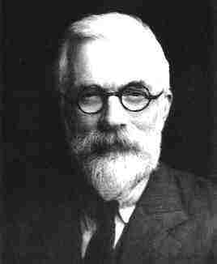

“…the object of statistical methods is the reduction of data. A quantity of data, which usually by its mere bulk is incapable of entering the mind, is to be replaced by relatively few quantities which shall adequately represent the whole, or…shall contain as much as possible, ideally the whole, of the relevant information contained in the original data.” ~ R.A. Fisher, 1921

## How We Describe Data Distributions

**Categorical Variables**

- frequency / relative frequency

*Summaries based on counting how many times categories occur.*

**Quantitative Variables**

- shape
- center
- spread
- outliers

*Shape*, *center*, and *spread* characterize the pattern of numerical observations. *Outliers* are deviations from the pattern.

## Exploring Categorical Data

- frequency table
- relative frequency table
- cumulative frequency table
- cumulative relative frequency table
- contingency table
- [bar chart / barplot](https://ggplot2.tidyverse.org/reference/geom_bar.html)
- pie chart

“There is no data that can be displayed in a pie chart that cannot be displayed better in some other type of chart.”

(Some people attribute this quote to John Tukey. That cannot be verified, but it is generally a true statement.)

## Frequency Table

*Frequency* is the total *count* of the how many observational units are found in each category of a categorical variable. A table that summarizes categories and their counts is a *frequency table*.

*Relative frequency* is the *fraction* of observations in each category of a particular categorical variable. Relative frequencies may be expressed as fractions, decimals, or percents. For example, 1/4 = 0.25 = 25%. We can tabulate categories and relative frequencies, with or without the categories’ frequencies.

The *probability* of an an event is often determined by observing relative frequency for that event.

*Cumulative frequency* is the frequency of a given category plus all categories that came before it in a given order. It is the “running total” of frequencies (or relative frequencies).

## Contingency Table

A contingency table is a type of frequency table that summarizes the relationship between two (or more) categorical variables in a matrix-type format. Sometimes they are referred to as two-way table or crosstabs. The rows of the table represent categories of one variable and the columns represent categories of the other variable. Other arrangements are also possible.

This kind of table may be used for several different types of data summaries, such as:

- observed counts
- row percentages
- column percentages
- overall percentages

## Berkeley Data

In the early 1970s, UC Berkeley was concerned about possible sex discrimination in grad school admissions. The berkeley.csv dataset contains fall 1973 data for the six largest departments. Click the link to get the URL for the dataset.

The Berkeley dataset is an example of a statistical phenomena called [Simpson’s Paradox](https://en.wikipedia.org/wiki/Simpson%27s_paradox).

Load the dataset into `R` from its URL:

`library(tidyverse)`

`berkdata <- read_csv(file = url("https://raw.githubusercontent.com/STAT-JET-ASU/Datasets/master/Instructor/berkeley.csv"))`

## Inspect the Dataset

```r
glimpse(berkdata)
```

```
Rows: 4,526
Columns: 3
$ sex        <chr> "male", "male", "male", "male", "male", "male", "male", "ma…
$ department <chr> "A", "A", "A", "A", "A", "A", "A", "A", "A", "A", "A", "A",…
$ status     <chr> "accepted", "accepted", "accepted", "accepted", "accepted",…
```

```r
head(berkdata, n = 3)
```

```
# A tibble: 3 × 3
  sex   department status
  <chr> <chr>      <chr>
1 male  A          accepted
2 male  A          accepted
3 male  A          accepted
```

## The Variables

There are three categorical variables in the Berkeley dataset.

- `sex`

whether the applicant was male or female (1970s definitions)

- `department`

the department to which the applicant applied (A through F)

- `status`

whether the applicant was accepted or rejected

Each *observation* in the dataset represents one applicant, with a total of 4526 observations.

## Frequency Tables

Base `R` contains two functions to make quick summary tables. Recall that the `$` notation is how we specify which variable we want in a dataset: `datasetname$variablename`.

```r
table(berkdata$status) # counts
```

```
accepted rejected
    1755     2771
```

```r
prop.table(table(berkdata$status))   # proportions add to 1 or 100%
```

```
 accepted  rejected
0.3877596 0.6122404
```

What class of object do `table()` and `prop.table()` produce?

## A `table()` Stored as an Object

We can store the results of `table()` as an object.

```r
statusTab <- table(berkdata$status)
prop.table(statusTab)
```

```
 accepted  rejected
0.3877596 0.6122404
```

```r
round(prop.table(statusTab), 4)   # note the nested functions
```

```
accepted rejected
  0.3878   0.6122
```

The table class of object in `R` is essentially an array where the locations have been named.

## Using dplyr to Make a “Table”

The `table()` function produces a structured vector or matrix. The method using the dplyr package produces a tibble.

```r
library(tidyverse)   # or library(dplyr)
berkdata %>% count(status)
```

```
# A tibble: 2 × 2
  status       n
  <chr>    <int>
1 accepted  1755
2 rejected  2771
```

Some functions such as `chisq.test()` expect vector or matrix input. Consider the reason for making the summary table. How might a tibble be advantageous in other ways?

Since the output created using `count()` is a tibble (i.e., dataset), the frequencies are a variable and we compute the proportions as a new variable using the `mutate()` function on column `n`.

```r
berkdata %>%
  count(status) %>%
  mutate(prop = prop.table(n))
```

```
# A tibble: 2 × 3
  status       n  prop
  <chr>    <int> <dbl>
1 accepted  1755 0.388
2 rejected  2771 0.612
```

Notice that we are still using the base `prop.table()` function to carry out the mutation of the counts to proportions. The display is rounded, but more decimals are calculated and stored.

Sometimes we want a running (cumulative) total of counts or proportions over several categories, usually ordered.

```r
berkdata %>%
  count(department) %>%
  arrange(desc(n)) %>%   # sorted by descending department size n
  mutate(prop      = prop.table(n),
         cum_count = cumsum(n),
         cum_prop  = cumsum(prop))    # prop column we made above
```

```
# A tibble: 6 × 5
  department     n  prop cum_count cum_prop
  <chr>      <int> <dbl>     <int>    <dbl>
1 A            933 0.206       933    0.206
2 C            918 0.203      1851    0.409
3 D            792 0.175      2643    0.584
4 F            714 0.158      3357    0.742
5 B            585 0.129      3942    0.871
6 E            584 0.129      4526    1
```

## Contingency or Two-way Tables

We can use two-way tables to explore the relationships between variables by looking how many cases fall in combinations of two variables’ categories. In this case, we see how many female and male applicants were accepted or rejected.

```r
table(berkdata$sex, berkdata$status)
```

```
         accepted rejected
  female      557     1278
  male       1198     1493
```

However, it is difficult to see the acceptance and rejection rates from this table. We can compute proportions similar to the way we did for a single variable.

```r
prop.table(table(berkdata$status)) # proportion table from earlier
```

```
 accepted  rejected
0.3877596 0.6122404
```

Here, we have proportions where separate rows add to 100%.

```r
prop.table(table(berkdata$sex, berkdata$status), 1) # rows is dim 1
```

```
          accepted  rejected
  female 0.3035422 0.6964578
  male   0.4451877 0.5548123
```

The overall acceptable rate was about 39%. However, a closer look shows that the acceptance rate for female applicants was about 30% versus about 45% for male applicants. Bias?

## Using dplyr for a “Two-Way Table”

```r
berkdata %>% count(sex, status)
```

```
# A tibble: 4 × 3
  sex    status       n
  <chr>  <chr>    <int>
1 female accepted   557
2 female rejected  1278
3 male   accepted  1198
4 male   rejected  1493
```

Computing proportions from this format requires manipulations using dplyr functions such as `group_by()` and `mutate()`.

The package *janitor* also includes a function [`tabyl()`](https://cran.r-project.org/web/packages/janitor/vignettes/tabyls.html) that makes nicely formatted tables when used with `adorn` functions.

## Using dplyr for Two-Way Proportions

```r
berkdata %>%
  group_by(sex) %>%   # perform calculations within each sex
  count(status) %>%   # count accepted and rejected students
  mutate(prop = prop.table(n))   # calculate proportions
```

```
# A tibble: 4 × 4
# Groups:   sex [2]
  sex    status       n  prop
  <chr>  <chr>    <int> <dbl>
1 female accepted   557 0.304
2 female rejected  1278 0.696
3 male   accepted  1198 0.445
4 male   rejected  1493 0.555
```

Notice that these values match the proportions we found with the `table()` and `prop.table()` functions.

## Back to the Question of Bias

Let’s look at relationships of sex and status with department.

```r
table(berkdata$sex, berkdata$department)
```

```
           A   B   C   D   E   F
  female 108  25 593 375 393 341
  male   825 560 325 417 191 373
```

```r
table(berkdata$status, berkdata$department)
```

```
             A   B   C   D   E   F
  accepted 601 370 322 269 147  46
  rejected 332 215 596 523 437 668
```

## Department Application Rates (%)

In graduate school, students apply directly to the department…

What percentage of applicants to each department was female?

```r
# nesting functions, make table, take column props, and round off
# in this contingency table, columns (departments) add up to 100%

round(prop.table(table(berkdata$sex, berkdata$department), 2), 4)
```

```
              A      B      C      D      E      F
  female 0.1158 0.0427 0.6460 0.4735 0.6729 0.4776
  male   0.8842 0.9573 0.3540 0.5265 0.3271 0.5224
```

Women apply at different rates to the six different apartments. The smallest percentages were Departments A and B.

## Department Acceptance Rates (%)

Did the six departments have different acceptance rates?

```r
# nesting functions, make table, take column props, and round off
# in this contingency table, columns (departments) add up to 100%

round(prop.table(table(berkdata$status, berkdata$department), 2), 4)
```

```
                A      B      C      D      E      F
  accepted 0.6442 0.6325 0.3508 0.3396 0.2517 0.0644
  rejected 0.3558 0.3675 0.6492 0.6604 0.7483 0.9356
```

Some of the departments accepted a much larger percentage of applicants than others. The largest was about 64% (Department A) and the smallest was about 6% (Department F).

## One More Way to Find Proportions

In some situations, we use a logic test to calculate proportions. This is often true when the variable is not in the form of binary categories, but we are interested in yes/no. In a logical vector, `TRUE` = 1 and `FALSE` = 0, thus algebraically the `mean()` function produces the proportions of 1’s.

```r
berkdata %>%
  group_by(sex) %>%
  summarize(prop_accept = mean(status == "accepted"))
```

```
# A tibble: 2 × 2
  sex    prop_accept
  <chr>        <dbl>
1 female       0.304
2 male         0.445
```

## The Very Useful Logic Test!

The code `berkdata$status == "accepted"` checks elements of the variable `status` and determines whether each is logically equal to the value `accepted`. The output is a logical vector.

```r
table(berkdata$status == "accepted")
```

```
FALSE  TRUE
 2771  1755
```

```r
table(berkdata$sex, berkdata$status == "accepted")
```

```
         FALSE TRUE
  female  1278  557
  male    1493 1198
```

## So Was There Bias?

We will revisit this dataset when we talk about chi-square tests later in the semester. An [article](https://science.sciencemag.org/content/187/4175/398) published in 1975 explored and summed up some of what we observed in the tables we made.

- Women were more likely to apply to departments that were harder to get into. There were far fewer female applicants to A and B, which accept more than 60% of all applicants. What looks like an overall bias is a result of this phenomenon. The individual departments sometimes *favor* women (which you will see when we revisit this dataset).
- What we can not tell from the dataset we have, but which the authors concluded, is that A and B had stronger mathematics prerequisites. Bias was likely occurring earlier in the pipeline, with women being advised into non-STEM areas.

## Another Example

The [STT3850majors.csv](https://raw.githubusercontent.com/STAT-JET-ASU/Datasets/master/Instructor/stt3850majors.csv) dataset contains information regarding students in Dr. Thomley’s past STT3850 classes.

`students <- read_csv(file = url("https://raw.githubusercontent.com/STAT-JET-ASU/Datasets/master/Instructor/stt3850majors.csv"))`

- College = ASU college the student is in (e.g., Arts & sciences)
- Year = student’s class year (e.g., freshman, sophomore)
- BannerMajor = student’s major as listed in banner
- CodedMajor = Dr. Thomley’s recoded list of majors
- Semester = the semester when the student took STT3850
- AY = academic year (e.g., 2018-2019)

## Which Academic Years?

```r
students %>% count(AY)
```

```
# A tibble: 8 × 2
  AY            n
  <chr>     <int>
1 2014-2015   172
2 2015-2016    95
3 2016-2017   103
4 2017-2018    58
5 2018-2019    86
6 2019-2020    91
7 2020-2021    61
8 2021-2022    98
```

Dr. Thomley has taught different numbers of STT3850 sections in the various years. Section sizes ranged from 25 to 45 (as an FYI—you can’t tell number or size directly from the dataset).

## What Majors? Oh, so many…

```r
students %>% count(BannerMajor)
```

```
# A tibble: 49 × 2
   BannerMajor                                 n
   <chr>                                   <int>
 1 Accounting                                  2
 2 Actuarial Science                          74
 3 Biology, Cell/Molecular Bio                 1
 4 Biology, Ecology,Evol & Environ Biology     1
 5 Business Analytics                          1
 6 Chemistry, Biochemistry                     1
 7 Chemistry, Certified Chemist                1
 8 Chemistry, Environmental                   13
 9 Chemistry, Fermentation Sciences            1
10 Chemistry, Individually Designed            1
# ℹ 39 more rows
```

## What Majors? Let’s be more concise…

```r
students %>%
  count(CodedMajor) %>%   # count the number of each major
  mutate(percents = 100 * prop.table(n))   # compute percentages
```

```
# A tibble: 4 × 3
  CodedMajor                n percents
  <chr>                 <int>    <dbl>
1 Computer Science        391    51.2
2 Mathematical Sciences   210    27.5
3 Other                    25     3.27
4 Other Sciences          138    18.1
```

So, it looks like the largest group overall is computer science majors. Has the % been constant across academic years?

```r
# since the output is a tibble, we can filter the results for CS!
students %>%
  group_by(AY) %>%
  count(CodedMajor) %>%
  mutate(percents = 100 * prop.table(n)) %>%
  filter(CodedMajor == "Computer Science")  # choose only CS rows
```

```
# A tibble: 8 × 4
# Groups:   AY [8]
  AY        CodedMajor           n percents
  <chr>     <chr>            <int>    <dbl>
1 2014-2015 Computer Science    98     57.0
2 2015-2016 Computer Science    48     50.5
3 2016-2017 Computer Science    47     45.6
4 2017-2018 Computer Science    26     44.8
5 2018-2019 Computer Science    35     40.7
6 2019-2020 Computer Science    39     42.9
7 2020-2021 Computer Science    34     55.7
8 2021-2022 Computer Science    64     65.3
```

## Class Years

```r
students %>%
  count(Year) %>%
  mutate(percents = 100 * prop.table(n))
```

```
# A tibble: 5 × 3
  Year                             n percents
  <chr>                        <int>    <dbl>
1 Freshman                        15    1.96
2 Graduate Certificate Program     1    0.131
3 Junior                         295   38.6
4 Senior                         313   41.0
5 Sophomore                      140   18.3
```

Notice the five `Year` categories are not in the standard order. We should probably convert the character variable to a factor. Then we can choose an order other than alphabetical.

## Major by Class Years

```r
students %>%
  count(CodedMajor, Year) %>%
  filter(CodedMajor == "Computer Science") %>%
  arrange(desc(n))
```

```
# A tibble: 4 × 3
  CodedMajor       Year          n
  <chr>            <chr>     <int>
1 Computer Science Senior      167
2 Computer Science Junior      159
3 Computer Science Sophomore    55
4 Computer Science Freshman     10
```

Many computer science majors seem quite likely to wait until they are seniors before they take this course. Can you explore these questions for other majors?